# Maximum Likelihood: Why the Best-Fitting Parameter Is Not a Probability

statistics

mathematics

inference

A coin-flip example explains what likelihood measures, derives the maximum-likelihood estimator, and shows how sample size changes uncertainty.

Published

September 14, 2026

## One expression, two directions

Suppose a coin lands heads 7 times in 10 independent flips. The unknown probability of heads is (p). It is tempting to say, “the probability that (p=0.7) is largest.” That sentence quietly confuses **probability** with **likelihood**.

Probability reasons forward: if (p) were known, how probable would the data be? For (K(n,p)),

$$\Pr(K=k\mid p)=\binom{n}{k}p^k(1-p)^{n-k}.$$

Likelihood reverses what varies. After observing (k), the data are fixed and candidate values of (p) are compared:

$$L(p\mid k,n)=\binom{n}{k}p^k(1-p)^{n-k}, \qquad 0\le p\le 1.$$

The formula is identical, but its role is different. As a function of (k), it is a probability distribution when (p) is fixed. As a function of (p), it is a likelihood when (k) is fixed. A likelihood need not sum or integrate to one over parameter values. Therefore, (L(0.7)) is not ((p=0.7K=7)); a probability distribution for (p) requires additional assumptions, such as a Bayesian prior.

## Comparing candidate coins

Because likelihoods can be extremely small, it is useful to divide every value by the largest one. This creates a **relative likelihood** whose maximum is 1 without changing which (p) fits best.

**Show reproducible R code**

```r
n <- 10
k <- 7

candidate_p <- c(0.30, 0.50, 0.70, 0.90)
candidate_loglik <- dbinom(k, size = n, prob = candidate_p, log = TRUE)
candidate_relative <- exp(candidate_loglik - max(candidate_loglik))

knitr::kable(data.frame(
  `Candidate p` = sprintf("%.2f", candidate_p),
  `Probability of exactly 7 heads` = sprintf("%.4f", exp(candidate_loglik)),
  `Relative likelihood` = sprintf("%.3f", candidate_relative),
  check.names = FALSE
))
```

Selected candidate values for the probability of heads.

| Candidate p | Probability of exactly 7 heads | Relative likelihood |
| --- | --- | --- |
| 0.30 | 0.0090 | 0.034 |
| 0.50 | 0.1172 | 0.439 |
| 0.70 | 0.2668 | 1.000 |
| 0.90 | 0.0574 | 0.215 |

Among these candidates, (p=0.7) supports the observed result most strongly. A smooth curve shows that it is also the best value among all candidates between 0 and 1.

**Show reproducible R code**

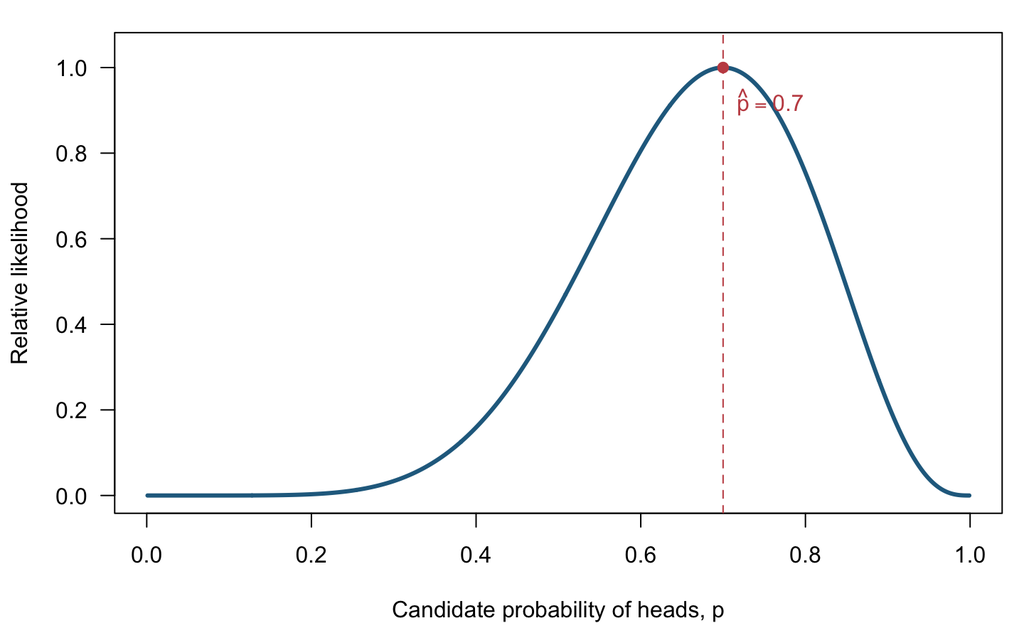

Figure 1: Relative likelihood after observing 7 heads in 10 flips. The curve compares parameter values; it is not a probability density for p.

```r
p_grid <- seq(0.001, 0.999, length.out = 1000)
loglik_10 <- dbinom(k, size = n, prob = p_grid, log = TRUE)
relative_10 <- exp(loglik_10 - max(loglik_10))

local({
  old <- par(mar = c(4.2, 4.2, 1.2, 0.8))
  on.exit(par(old))
  plot(p_grid, relative_10, type = "l", lwd = 3, col = "#246B8E",
       xlab = "Candidate probability of heads, p",
       ylab = "Relative likelihood", ylim = c(0, 1.04), las = 1)
  abline(v = k / n, lty = 2, col = "#C44E52")
  points(k / n, 1, pch = 19, col = "#C44E52")
  text(k / n, 0.91, expression(hat(p) == 0.7), pos = 4,
       col = "#C44E52")
})
```

## Why the maximum is the sample proportion

Products are easier to differentiate after taking logarithms. Since logarithms are strictly increasing, maximizing (L) is equivalent to maximizing the log-likelihood:

$$\ell(p)=\log L(p)=\log\binom{n}{k}+k\log p+(n-k)\log(1-p).$$

For (0<k<n), differentiate and set the score equal to zero:

$$\ell'(p)=\frac{k}{p}-\frac{n-k}{1-p}=0
\quad\Longrightarrow\quad
k(1-p)=(n-k)p
\quad\Longrightarrow\quad
\widehat p=\frac{k}{n}.$$

This stationary point is the unique maximum because

$$\ell''(p)=-\frac{k}{p^2}-\frac{n-k}{(1-p)^2}<0
\qquad (0<p<1).$$

Thus the entire log-likelihood is strictly concave. If (k=0) or (k=n), there is no interior stationary point; the maximum occurs at the boundary, (p=0) or (1). These cases matter because blindly solving a derivative equation would miss them.

## Same estimate, different evidence

Now compare 7 heads in 10 flips with 70 heads in 100 flips. Both give (p=0.7), but the larger experiment should tell us more. Its likelihood curve is much sharper.

**Show reproducible R code**

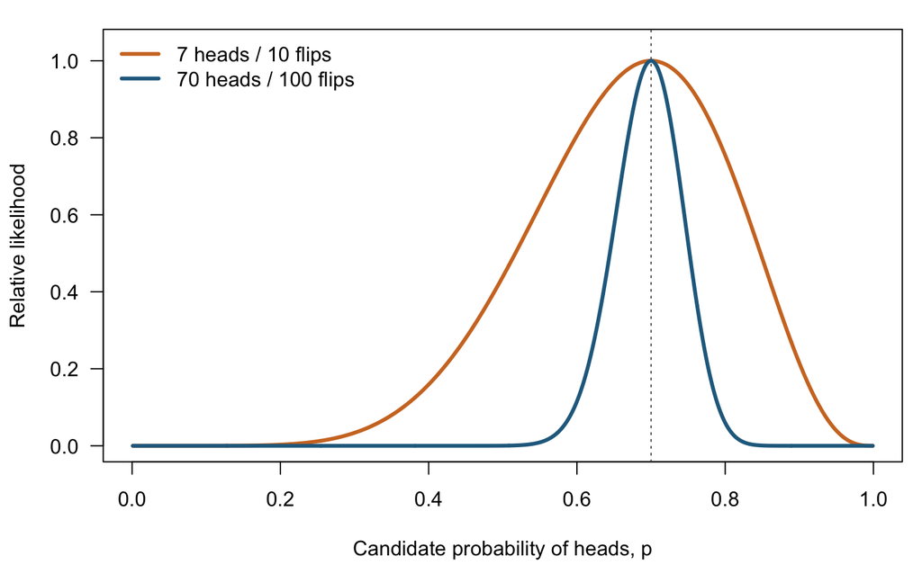

Figure 2: Both samples have the same maximum-likelihood estimate, but 70 heads in 100 flips produces a more concentrated likelihood.

```r
relative_likelihood <- function(p, successes, trials) {
  values <- dbinom(successes, size = trials, prob = p, log = TRUE)
  exp(values - max(values))
}

rel_10 <- relative_likelihood(p_grid, 7, 10)
rel_100 <- relative_likelihood(p_grid, 70, 100)

local({
  old <- par(mar = c(4.2, 4.2, 1.2, 0.8))
  on.exit(par(old))
  plot(p_grid, rel_10, type = "l", lwd = 3, col = "#D07629",
       xlab = "Candidate probability of heads, p",
       ylab = "Relative likelihood", ylim = c(0, 1.04), las = 1)
  lines(p_grid, rel_100, lwd = 3, col = "#246B8E")
  abline(v = 0.7, lty = 3, col = "grey35")
  legend("topleft", c("7 heads / 10 flips", "70 heads / 100 flips"),
         col = c("#D07629", "#246B8E"), lwd = 3, bty = "n")
})
```

The connection is mathematical. At the maximum,

$$-\ell''(\widehat p)=\frac{n}{\widehat p(1-\widehat p)}.$$

Larger (n) creates greater curvature and a narrower peak. In regular large samples, the inverse curvature gives the approximation

$$\operatorname{SE}(\widehat p)\approx
\sqrt{\frac{\widehat p(1-\widehat p)}{n}}.$$

It equals about 0.145 for 7/10 and 0.046 for 70/100. This approximation can be poor for small samples or estimates near 0 or 1, so the shape of the likelihood remains informative.

## Assumptions, source, and takeaway

The numbers are constructed for this explanation; no external dataset is used. The binomial model assumes a fixed number of independent flips with one constant (p). Dependence or a changing coin would require a different likelihood. R. A. Fisher’s [1922 paper on the foundations of theoretical statistics](https://doi.org/10.1098/rsta.1922.0009) helped formalize likelihood as distinct from inverse probability.

**NoteTakeaway**

Maximum likelihood ranks parameter values by how well they explain fixed, observed data. The maximizer (p=k/n) is a point estimate, not the probability that the parameter is correct. The peak’s width supplies the missing second lesson: two identical estimates can carry very different amounts of information.